# DATA1001/1901 Lab5

Linear Model

© University of Sydney 2021

# 1 Live Demo

We will demonstrate linear modelling.

```r
# Consider the iris data
dim(iris)
```

```
## [1] 150   5
```

```r
str(iris)
```

```
## 'data.frame':    150 obs. of  5 variables:
##  $ Sepal.Length: num  5.1 4.9 4.7 4.6 5 5.4 4.6 5 4.4 4.9 ...
##  $ Sepal.Width : num  3.5 3 3.2 3.1 3.6 3.9 3.4 3.4 2.9 3.1 ...
##  $ Petal.Length: num  1.4 1.4 1.3 1.5 1.4 1.7 1.4 1.5 1.4 1.5 ...
##  $ Petal.Width : num  0.2 0.2 0.2 0.2 0.2 0.4 0.3 0.2 0.2 0.1 ...
##  $ Species     : Factor w/ 3 levels "setosa","versicolor",..: 1 1 1 1 1 1 1 1 1 1 ...
```

## 1.1 Research Question: Is there a linear relationship between Petal Width (x) and Petal Length (y)?

Note: Your research question concerning a linear model should involve 2 quantitative variables.

```r
# Step1: Construct a scatter plot
plot(iris$Petal.Width,iris$Petal.Length)    # Note the order: plot(x,y)

# Step2: Calculate the linear regression model and draw on the scatter plot
L=lm(iris$Petal.Length ~ iris$Petal.Width)    # Note the order: lm(y ~ x)
summary(L)
```

```
##
## Call:
## lm(formula = iris$Petal.Length ~ iris$Petal.Width)
##
## Residuals:
##      Min       1Q   Median       3Q      Max
## -1.33542 -0.30347 -0.02955  0.25776  1.39453
##
## Coefficients:
##                  Estimate Std. Error t value Pr(>|t|)
## (Intercept)       1.08356    0.07297   14.85   <2e-16 ***
## iris$Petal.Width  2.22994    0.05140   43.39   <2e-16 ***
## ---
## Signif. codes:  0 '***' 0.001 '**' 0.01 '*' 0.05 '.' 0.1 ' ' 1
##
## Residual standard error: 0.4782 on 148 degrees of freedom
## Multiple R-squared:  0.9271, Adjusted R-squared:  0.9266
## F-statistic:  1882 on 1 and 148 DF,  p-value: < 2.2e-16
```

```r
L$coeff
```

```
##      (Intercept) iris$Petal.Width
##         1.083558         2.229940
```

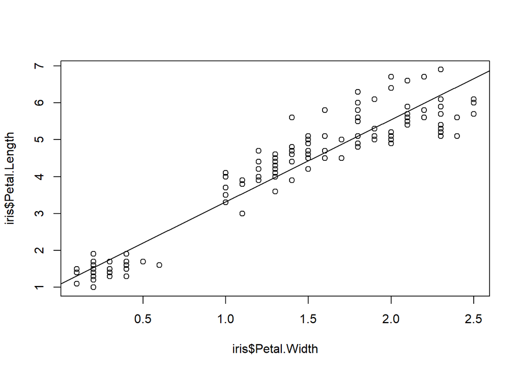

```r
abline(L)
```

```r
# Step3: Calculate the (linear) correlation coefficient
cor(iris$Petal.Width,iris$Petal.Length)    # Note the order doesn't matter :)
```

```
## [1] 0.9628654
```

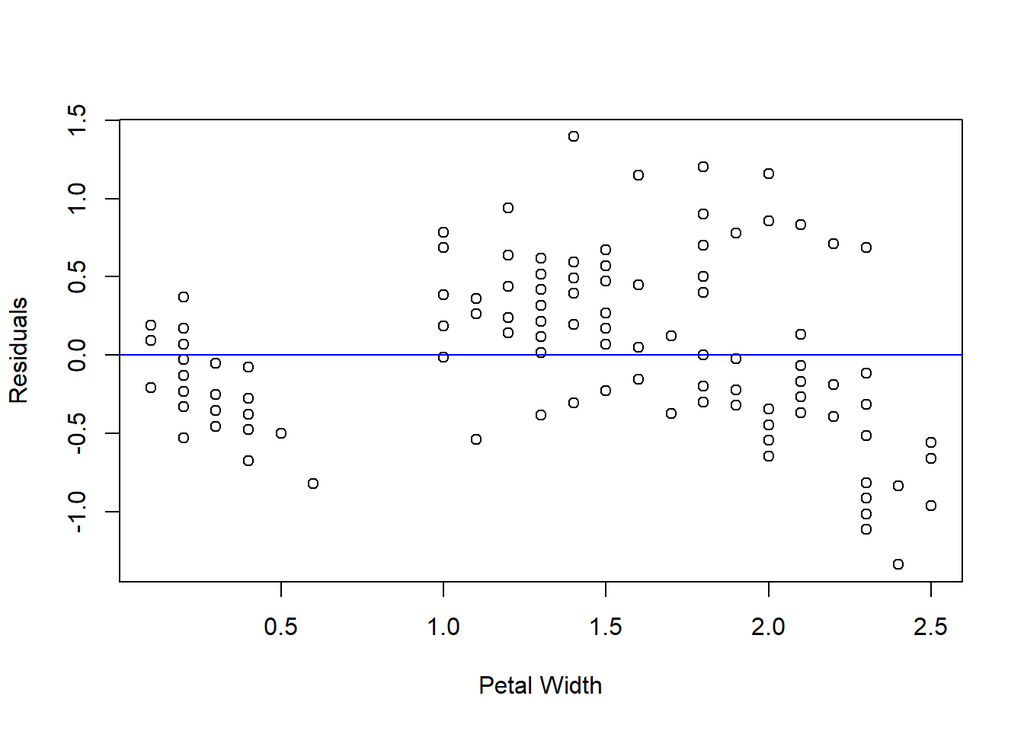

```r
# Step4: Construct the residual plot (diagnostic)
plot(iris$Petal.Width, L$residuals, xlab = "Petal Width", ylab = "Residuals")
abline(h = 0, col = "blue")
```

```r
# Step5 (If appropriate): Predict the Petal Length of an iris with Petal Width of 2
unname(L$coeff[1]) + unname(L$coeff[2])*2
```

```
## [1] 5.543439
```

Conclusion:

Now let’s try in ggplot!

```r
library(tidyverse)
```

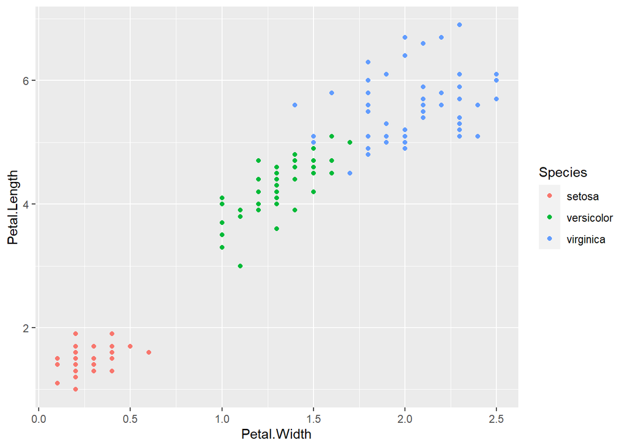

```r
ggplot(iris, aes(x=Petal.Width, y = Petal.Length, colour = Species)) + geom_point()
```

# 2 Air Quality in Sydney

Have a go at linear regression yourself!

## 2.1 Data Story

- The Sydney Air Quality dataset comes from [Environment NSW](http://www.environment.nsw.gov.au/AQMS/search.htm).

```r
air = read.csv("http://www.maths.usyd.edu.au/u/UG/JM/DATA1001/r/current/data/AQI_July2015.csv")

# IDA
dim(air)
```

```
## [1] 31  3
```

```r
str(air)
```

```
## 'data.frame':    31 obs. of  3 variables:
##  $ ï..Date    : Factor w/ 31 levels "01/07/2015","02/07/2015",..: 1 2 3 4 5 6 7 8 9 10 ...
##  $ SydneyCEAQI: int  99 32 70 74 95 71 31 58 108 82 ...
##  $ SydneyNWAQI: int  92 44 82 96 100 98 65 71 74 67 ...
```

- According to this [AQI Info](http://www.health.nsw.gov.au/environment/air/Pages/aqi.aspx), what is the AQI? What does it measure? Why is it important?
- Check out this scary [visualisation](http://aqicn.org/map/). What stands out?

## 2.2 What day had the worst air quality?

```r
summary(air)
```

```
##        ï..Date    SydneyCEAQI      SydneyNWAQI
##  01/07/2015: 1   Min.   : 30.00   Min.   : 33.00
##  02/07/2015: 1   1st Qu.: 35.50   1st Qu.: 38.50
##  03/07/2015: 1   Median : 41.00   Median : 54.00
##  04/07/2015: 1   Mean   : 50.77   Mean   : 56.13
##  05/07/2015: 1   3rd Qu.: 60.50   3rd Qu.: 67.00
##  06/07/2015: 1   Max.   :108.00   Max.   :100.00
##  (Other)   :25
```

## 2.3 Which region has the best air quality?

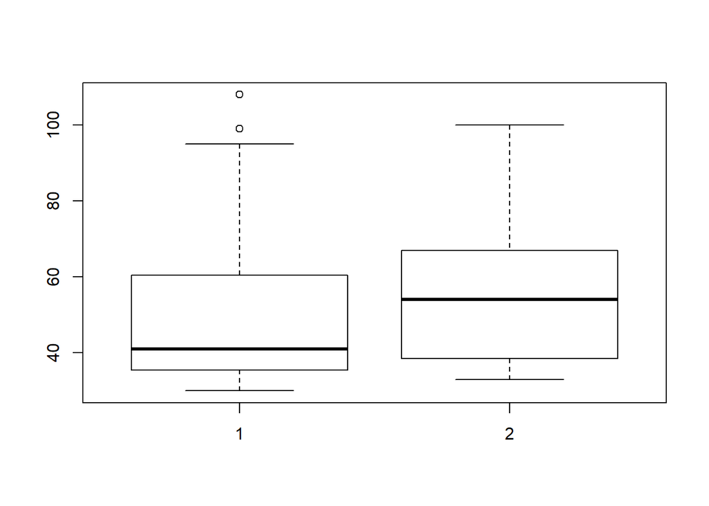

```r
boxplot(air$SydneyCEAQI,air$SydneyNWAQI)
```

## 2.4 Is there a linear relationship between the air quality in the 2 regions?

```r
# Step1: Construct a scatter plot

# Step2: Calculate the linear regression model and draw on the scatter plot

# Step3: Calculate the (linear) correlation coefficient

# Step4: Construct the residual plot (diagnostic)

# Step5 (If appropriate): Predict the air quality in NW Sydney on a day when the air quality in CE Sydney is 120
```

# 3 Olympic 100m sprint

## 3.1 Data Story

- The 100m men’s sprint is considered once of the most prestigous events at each Olympics. Who holds the current record, and for what time? See [Olympic times](https://www.olympic.org/athletics/100m-men.
- Study the following code, and then fill in the research questions it is answering. What did you discover?

```r
## IDA
olympics = read.csv("http://www.maths.usyd.edu.au/u/UG/JM/DATA1001/r/current/data/Olympics100m.csv")
dim(olympics)
```

```
## [1] 50  7
```

```r
str(olympics)
```

```
## 'data.frame':    50 obs. of  7 variables:
##  $ Year   : int  1896 1900 1904 1906 1908 1912 1920 1924 1928 1932 ...
##  $ X      : Factor w/ 43 levels "Allan Wells",..: 38 18 3 3 34 33 9 20 32 11 ...
##  $ Time   : num  12 11 11 11.2 10.8 ...
##  $ Country: Factor w/ 15 levels "AUS","BLR","CAN",..: 15 15 15 15 12 15 15 5 3 15 ...
##  $ Gender : Factor w/ 2 levels "female","male": 2 2 2 2 2 2 2 2 2 2 ...
##  $ X.1    : logi  NA NA NA NA NA NA ...
##  $ X.2    : logi  NA NA NA NA NA NA ...
```

## 3.2 Research Questions

- Study the following code. Fill in the research questions it is answering. What did you discover?

```r
## RQ1: <fill in>
Men = olympics$Time[olympics$Gender=="male"]
max(Men)
```

```
## [1] 12
```

```r
## RQ2: <fill in>
Women = olympics$Time[olympics$Gender=="female"]
min(Women)
```

```
## [1] 10.54
```

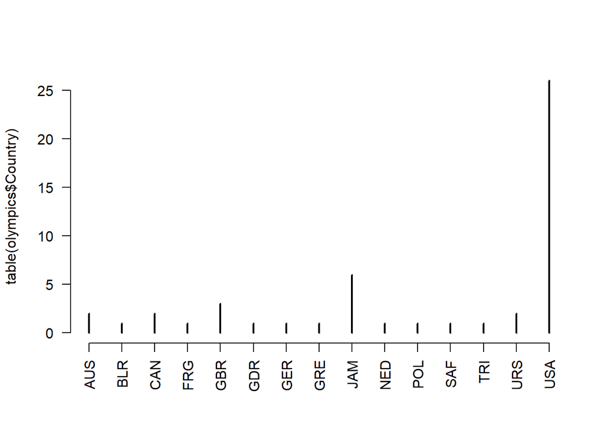

```r
## RQ3: <fill in>
plot(table(olympics$Country),las=2)
```

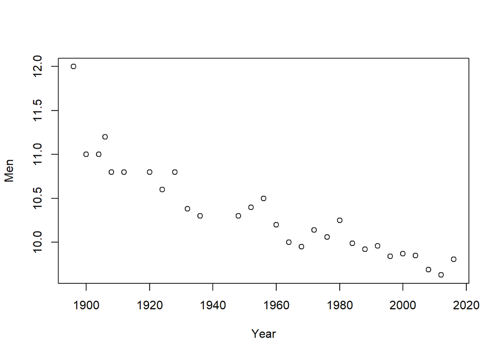

```r
## RQ4: <fill in>
Year = olympics$Year[olympics$Gender=="male"]
plot(Year,Men)
```

```r
cor(Year,Men)
```

```
## [1] -0.9114649
```

```r
lm(Men~Year)
```

```
##
## Call:
## lm(formula = Men ~ Year)
##
## Coefficients:
## (Intercept)         Year
##    35.65353     -0.01293
```

- Note if you try to regress the men’s winning time on women’s winning time for each year, you get an error message. Why?

```r
L=lm(Men~Women)
length(Men)
length(Women)
```

Here’s a possible solution.

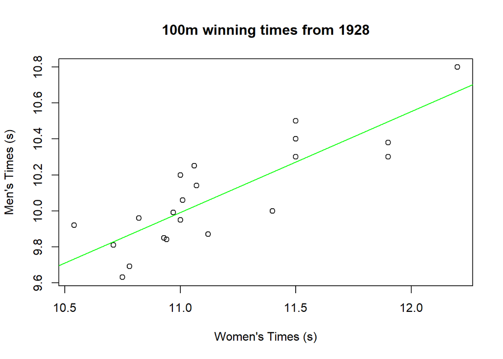

```r
# Make the Men's data the same length as Women, by starting from 1928
Men1 = olympics$Time[olympics$Gender == "male" & (olympics$Year > 1927)]
plot(Women, Men1, main = "100m winning times from 1928", xlab = "Women's Times (s)", ylab = "Men's Times (s)")
L1 = lm(Men1 ~ Women)
abline(L1, col = "green")
```

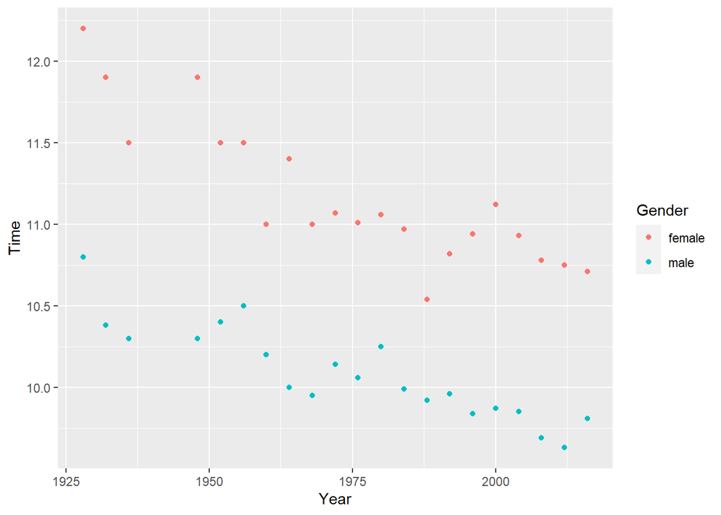

```r
# Now we do in ggplot
library(tidyverse)
olympics %>% filter(Year  > 1927)  %>% select(Year, Time, Gender) %>% ggplot(aes(x=Year, y = Time, colour = Gender)) + geom_point()
```